# US ARMS TRANSFER DATA

Inthisar Kamal

09/12/2020

```r
#install.packages("leaflet")
#install.packages("widgetframe")
#install.packages("htmlwidgets")
#install.packages("rworldmap")
#install.packages("emojifont")
```

```r
library(tidyverse)
```

```r
library(ggplot2)
library(lubridate)
library(maps)
library(wesanderson)
library(ggthemes)
library(dplyr)
library(extrafont)
library(plyr)
library(scales)
library(janitor)
library(readxl)
library(countrycode)
library(ggthemes)
library(ggrepel)
library(dslabs)
library(leaflet)
library(widgetframe)
library(htmlwidgets)
library(plotly)
library(wesanderson)
library(emojifont)
```

Top 20 Exporters of arms in the last 20 years

```r
Top_20_Recent <- read.csv("/Users/inthisarkamal/Desktop/DS4PP/Final Project/TER.csv")

Top_20_Recent
```

```
##    Latitude Longitude       Supplier X2000 X2001 X2002 X2003 X2004 X2005 X2006
## 1   40.0000 -100.0000  United States  7577  5606  4947  5659  6843  6770  7521
## 2   61.5240  105.3188         Russia  4503  5291  5746  5169  6288  5229  5159
## 3   46.2276    2.2137         France  1082  1416  1433  1400  2283  1817  1666
## 4   51.1657   10.4515        Germany  1612   896   906  1652  1111  2071  2758
## 5   55.3781    3.4360 United Kingdom  1633  1387  1100   754  1216  1060   997
## 6   35.8617  104.1954          China   299   515   525   700   413   286   668
## 7   40.4637    3.7492          Spain    46     8    16    95    52   108   840
## 8   31.0461   34.8516         Israel   404   474   579   409   609   510   406
## 9   41.8719   12.5674          Italy   208   270   467   365   263   832   553
## 10  52.1326    5.2913    Netherlands   284   203   233   331   204   505  1146
## 11  48.3794   31.1656        Ukraine   270   511   310   306   199   291   531
## 12  60.1282   18.6435         Sweden   359   895   163   515   294   534   390
## 13  35.9078  127.7669    South Korea    10   228    NA    96    73   108   158
## 14  46.8182    8.2275    Switzerland   182   209   166   185   255   253   296
```

[output cut: 57 more lines]

```r
Top_20_Recent2 <- Top_20_Recent [-c((21:23)),]
```

```r
Top_20_Recent %>%
  leaflet() %>%
  addTiles() %>%
  addMarkers(clusterOptions = markerClusterOptions(), label = ~Supplier)
```

```
## Assuming "Longitude" and "Latitude" are longitude and latitude, respectively
```

[interactive chart not shown]

Top 20 Exporters from 2000 to 2019

```r
Top_20_AllTime <- read.csv("/Users/inthisarkamal/Desktop/DS4PP/Final Project/Top 20 Exporters.csv")
```

```r
Top_20_1950_2000 <- Top_20_AllTime[-c(2001,2019)]

Top_20_1950_2000
```

```
##    Latitude Longitude       Supplier X1950 X1951 X1952 X1953 X1954 X1955 X1956
## 1   40.0000 -100.0000  United States  1429  4052  6391  9177  5857  6867  8492
## 2   61.5000  105.0000   Soviet Union  3985  3770  6018  7988  9024  6194  6442
## 3   61.5000  105.0000         Russia    NA    NA    NA    NA    NA    NA    NA
## 4   55.3781    3.4360 United Kingdom  2250  3459  3244  4622  5216  4835  5966
## 5   46.2276    2.2137         France     8    67    43   315   322   469   863
## 6   51.1657   10.4515        Germany    NA    NA    NA    38    29    24    24
## 7   35.8617  104.1954          China    NA    NA    NA    NA     3    NA    39
## 8   41.8719   12.5674          Italy   141   117    24     1    11   140   257
## 9   49.8175   15.4730 Czechoslovakia    17    15    15     9    49   950  1560
## 10  52.1326    5.2913    Netherlands   199    58    21     7    77   255     9
## 11  31.0461   34.8516         Israel    NA    NA    NA    NA     8    30    NA
## 12  46.8182    8.2275    Switzerland    NA    NA    NA    NA    NA    NA    NA
## 13  40.4637    3.7492          Spain    NA    NA    NA    NA    NA    NA    NA
## 14  60.1282   18.6435         Sweden    27    46    64   165    21   105    96
```

[output cut: 153 more lines]

```r
Top_20_1950_2000B <-Top_20_1950_2000 [-c((20:23)),]
```

```r
Top_20_1950_2000B %>%
  leaflet() %>%
  addTiles() %>%
  addMarkers(clusterOptions = markerClusterOptions(), label = ~Supplier)
```

```
## Assuming "Longitude" and "Latitude" are longitude and latitude, respectively
```

[interactive chart not shown]

Top 20 Exporters between 1950 to 2000

Which countries are the top exporters?

```r
Top_20 <- Top_20_AllTime [-c((21:23)),]
Top_20
```

```
##    Latitude Longitude       Supplier X1950 X1951 X1952 X1953 X1954 X1955 X1956
## 1   40.0000 -100.0000  United States  1429  4052  6391  9177  5857  6867  8492
## 2   61.5000  105.0000   Soviet Union  3985  3770  6018  7988  9024  6194  6442
## 3   61.5000  105.0000         Russia    NA    NA    NA    NA    NA    NA    NA
## 4   55.3781    3.4360 United Kingdom  2250  3459  3244  4622  5216  4835  5966
## 5   46.2276    2.2137         France     8    67    43   315   322   469   863
## 6   51.1657   10.4515        Germany    NA    NA    NA    38    29    24    24
## 7   35.8617  104.1954          China    NA    NA    NA    NA     3    NA    39
## 8   41.8719   12.5674          Italy   141   117    24     1    11   140   257
## 9   49.8175   15.4730 Czechoslovakia    17    15    15     9    49   950  1560
## 10  52.1326    5.2913    Netherlands   199    58    21     7    77   255     9
## 11  31.0461   34.8516         Israel    NA    NA    NA    NA     8    30    NA
## 12  46.8182    8.2275    Switzerland    NA    NA    NA    NA    NA    NA    NA
## 13  40.4637    3.7492          Spain    NA    NA    NA    NA    NA    NA    NA
## 14  60.1282   18.6435         Sweden    27    46    64   165    21   105    96
```

[output cut: 132 more lines]

```r
names(Top_20) <- gsub ("X", "", names(Top_20))
Top_20
```

```
##    Latitude Longitude       Supplier 1950 1951 1952 1953 1954 1955 1956 1957
## 1   40.0000 -100.0000  United States 1429 4052 6391 9177 5857 6867 8492 8659
## 2   61.5000  105.0000   Soviet Union 3985 3770 6018 7988 9024 6194 6442 6661
## 3   61.5000  105.0000         Russia   NA   NA   NA   NA   NA   NA   NA   NA
## 4   55.3781    3.4360 United Kingdom 2250 3459 3244 4622 5216 4835 5966 4994
## 5   46.2276    2.2137         France    8   67   43  315  322  469  863  661
## 6   51.1657   10.4515        Germany   NA   NA   NA   38   29   24   24   44
## 7   35.8617  104.1954          China   NA   NA   NA   NA    3   NA   39   30
## 8   41.8719   12.5674          Italy  141  117   24    1   11  140  257  275
## 9   49.8175   15.4730 Czechoslovakia   17   15   15    9   49  950 1560 1576
## 10  52.1326    5.2913    Netherlands  199   58   21    7   77  255    9    8
## 11  31.0461   34.8516         Israel   NA   NA   NA   NA    8   30   NA    4
## 12  46.8182    8.2275    Switzerland   NA   NA   NA   NA   NA   NA   NA   NA
## 13  40.4637    3.7492          Spain   NA   NA   NA   NA   NA   NA   NA   NA
## 14  60.1282   18.6435         Sweden   27   46   64  165   21  105   96  111
```

[output cut: 132 more lines]

```r
colnames(Top_20)[colnames(Top_20) %in% c("Supplier", "1950.2019")] <- c("Exporter", "Total Value")
Top_20
```

```
##    Latitude Longitude       Exporter 1950 1951 1952 1953 1954 1955 1956 1957
## 1   40.0000 -100.0000  United States 1429 4052 6391 9177 5857 6867 8492 8659
## 2   61.5000  105.0000   Soviet Union 3985 3770 6018 7988 9024 6194 6442 6661
## 3   61.5000  105.0000         Russia   NA   NA   NA   NA   NA   NA   NA   NA
## 4   55.3781    3.4360 United Kingdom 2250 3459 3244 4622 5216 4835 5966 4994
## 5   46.2276    2.2137         France    8   67   43  315  322  469  863  661
## 6   51.1657   10.4515        Germany   NA   NA   NA   38   29   24   24   44
## 7   35.8617  104.1954          China   NA   NA   NA   NA    3   NA   39   30
## 8   41.8719   12.5674          Italy  141  117   24    1   11  140  257  275
## 9   49.8175   15.4730 Czechoslovakia   17   15   15    9   49  950 1560 1576
## 10  52.1326    5.2913    Netherlands  199   58   21    7   77  255    9    8
## 11  31.0461   34.8516         Israel   NA   NA   NA   NA    8   30   NA    4
## 12  46.8182    8.2275    Switzerland   NA   NA   NA   NA   NA   NA   NA   NA
## 13  40.4637    3.7492          Spain   NA   NA   NA   NA   NA   NA   NA   NA
## 14  60.1282   18.6435         Sweden   27   46   64  165   21  105   96  111
```

[output cut: 132 more lines]

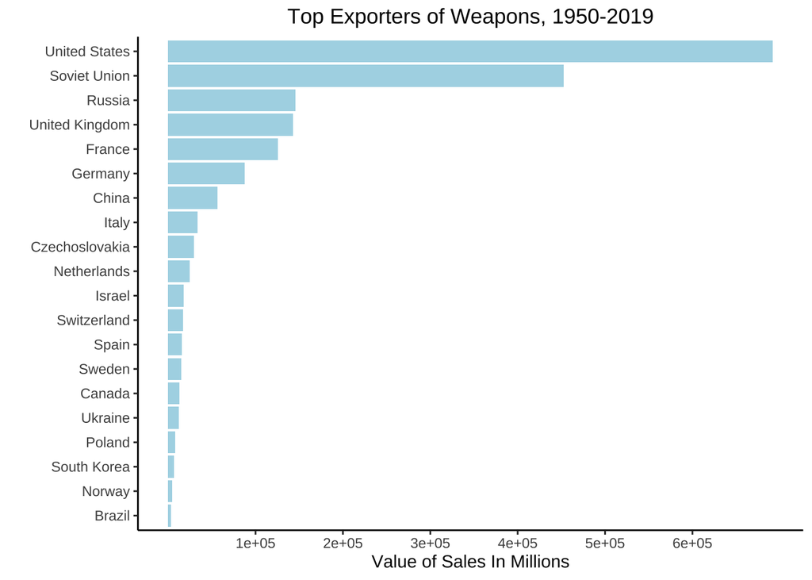

```r
Top_20 %>%
  ggplot(mapping = aes(x=fct_reorder(Exporter, `Total Value`, .desc = FALSE), y= `Total Value`))+
  geom_bar(stat="identity", position = "dodge", fill="lightblue")+
  labs(title = "Top Exporters of Weapons, 1950-2019", y="Value of Sales In Millions", x="",  fill=FALSE)+
  theme_classic()+
  coord_flip()+
  theme(legend.position = "none")+
  theme(plot.title=element_text(hjust=0.5))+
  scale_y_continuous(breaks = c(100000, 200000, 300000, 400000, 500000, 600000))
```

Looking at the top 100 companies in Arms Manufacturing

```r
Companies <- read.csv("/Users/inthisarkamal/Desktop/DS4PP/Final Project/Top_100_Companies.csv")
```

```r
Companies <- Companies [-c(111,112,113,114,115,116,117,118,119,120),]
Companies
```

```
##     X2017.Rank
## 1            1
## 2            2
## 3            3
## 4            4
## 5            5
## 6            6
## 7            7
## 8            8
## 9            9
## 10          10
## 11          11
## 12          12
## 13          13
## 14          14
```

[output cut: 429 more lines]

```r
Companies %>%
  distinct(Country)
```

```
##           Country
## 1   United States
## 2  United Kingdom
## 3  Trans-European
## 4          France
## 5           Italy
## 6          Russia
## 7           Japan
## 8         Germany
## 9          Israel
## 10         Sweden
## 11          India
## 12    South Korea
## 13      Singapore
## 14         Turkey
## 15         Poland
## 16      Australia
## 17        Ukraine
## 18         Brazil
## 19          Spain
## 20    Switzerland
## 21
```

```r
Pie_Companies_By_Nationality <-Companies %>%
  count('Country')

Pie_Companies_By_Nationality
```

```
##           Country freq
## 1                    2
## 2       Australia    1
## 3          Brazil    1
## 4          France    7
## 5         Germany    4
## 6           India    3
## 7          Israel    3
## 8           Italy    2
## 9           Japan    5
## 10         Poland    1
## 11         Russia   10
## 12      Singapore    1
## 13    South Korea    4
## 14          Spain    1
## 15         Sweden    1
## 16    Switzerland    1
## 17 Trans-European    2
## 18         Turkey    2
## 19        Ukraine    1
## 20 United Kingdom    9
## 21  United States   49
```

```r
Companies_By_Nationality <- Pie_Companies_By_Nationality [-c(1),]
```

```r
Companies_By_Nationality
```

```
##           Country freq
## 2       Australia    1
## 3          Brazil    1
## 4          France    7
## 5         Germany    4
## 6           India    3
## 7          Israel    3
## 8           Italy    2
## 9           Japan    5
## 10         Poland    1
## 11         Russia   10
## 12      Singapore    1
## 13    South Korea    4
## 14          Spain    1
## 15         Sweden    1
## 16    Switzerland    1
## 17 Trans-European    2
## 18         Turkey    2
## 19        Ukraine    1
## 20 United Kingdom    9
## 21  United States   49
```

```r
fcountry <- c(1, 1, 7, 4, 3, 3, 2, 5, 1, 10, 1, 4, 1, 1, 1, 2, 2, 1, 9, 49)
```

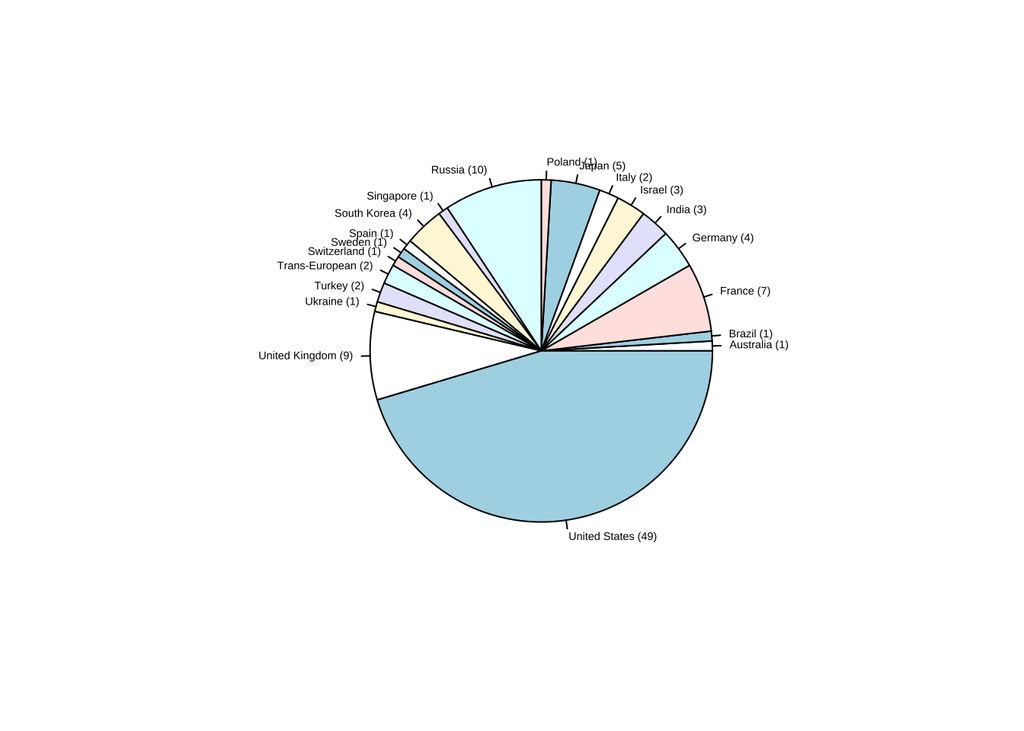

```r
pie(fcountry, labels=c("Australia (1)", "Brazil (1)", "France (7)", "Germany (4)", "India (3)", "Israel (3)", "Italy (2)", "Japan (5)", "Poland (1)", "Russia (10)", "Singapore (1)", "South Korea (4)", "Spain (1)", "Sweden (1)", "Switzerland (1)", "Trans-European (2)", "Turkey (2)", "Ukraine (1)", "United Kingdom (9)", "United States (49)", main = "Nationality of Top 100 Companies"), cex=0.45)
```

#open in a separate window, labels appear cramped in smaller viewing window 49 out of 100 of the top 100 companies are American companies. Let’s look at revenue.

```r
Top_20
```

```
##    Latitude Longitude       Exporter 1950 1951 1952 1953 1954 1955 1956 1957
## 1   40.0000 -100.0000  United States 1429 4052 6391 9177 5857 6867 8492 8659
## 2   61.5000  105.0000   Soviet Union 3985 3770 6018 7988 9024 6194 6442 6661
## 3   61.5000  105.0000         Russia   NA   NA   NA   NA   NA   NA   NA   NA
## 4   55.3781    3.4360 United Kingdom 2250 3459 3244 4622 5216 4835 5966 4994
## 5   46.2276    2.2137         France    8   67   43  315  322  469  863  661
## 6   51.1657   10.4515        Germany   NA   NA   NA   38   29   24   24   44
## 7   35.8617  104.1954          China   NA   NA   NA   NA    3   NA   39   30
## 8   41.8719   12.5674          Italy  141  117   24    1   11  140  257  275
## 9   49.8175   15.4730 Czechoslovakia   17   15   15    9   49  950 1560 1576
## 10  52.1326    5.2913    Netherlands  199   58   21    7   77  255    9    8
## 11  31.0461   34.8516         Israel   NA   NA   NA   NA    8   30   NA    4
## 12  46.8182    8.2275    Switzerland   NA   NA   NA   NA   NA   NA   NA   NA
## 13  40.4637    3.7492          Spain   NA   NA   NA   NA   NA   NA   NA   NA
## 14  60.1282   18.6435         Sweden   27   46   64  165   21  105   96  111
```

[output cut: 132 more lines]

```r
Finance <- read.csv("/Users/inthisarkamal/Desktop/DS4PP/Final Project/Top_5.csv")
```

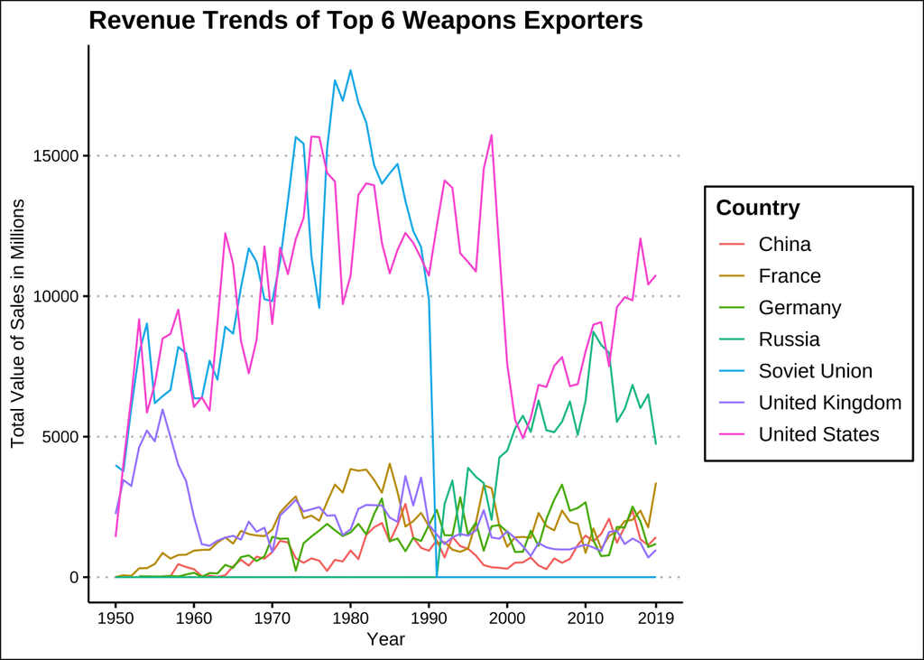

```r
Six_largest_Countries <- c("United States", "Russia", "Soviet Union", "China", "Germany", "United Kingdom", "France")

Finance %>%
  filter(Country %in% Six_largest_Countries) %>%
  ggplot(mapping = aes(x = Year, y = Total, col = Country)) +
  geom_line() +
  labs(x= "Year",
       y= "Total Value of Sales in Millions",
       title = "Revenue Trends of Top 6 Weapons Exporters") +
  scale_x_continuous(breaks = c(1950, 1960, 1970, 1980, 1990, 2000, 2010, 2019))+
  theme_clean()
```

Graph above shows the revenue trends of the top six weapons manufacturing countries from 1950 to 2019. Note that Soviet Union breaks off around 1990 when Russia is formed. Clearly USA is the biggest exporter of arms. Let’s see who they import to.

```r
Nation <- read.csv("/Users/inthisarkamal/Desktop/DS4PP/Final Project/Total_Exports.csv")
```

```r
colnames(Nation) <- c("Year", "Country", "Value")
Nation
```

```
##      Year                    Country Value
## 1    1950                  Argentina    70
## 2    1950                    Belgium    35
## 3    1950                     Canada   216
## 4    1950                      Chile     1
## 5    1950                   Colombia     3
## 6    1950                    Denmark    17
## 7    1950         Dominican Republic     2
## 8    1950                      Egypt    24
## 9    1950                El Salvador     1
## 10   1950                     France   218
## 11   1950                     Greece    95
## 12   1950                      Haiti     4
## 13   1950                  Indonesia     0
## 14   1950                       Iran     4
```

[output cut: 3813 more lines]

Top US imports between 1950-1980: Cold War leading up to the Iranian Revolution

```r
Top_Importers_50_to_80<-Nation %>%
  filter(Year %in% c(1950:1980))%>%
  group_by(Country) %>%
  select(Country, Value) %>%
  summarise_each(funs(sum)) %>%
  arrange(desc(Value))
Top_Importers_50_to_80
```

```
## # A tibble: 112 x 2
##    Country        Value
##    <chr>          <int>
##  1 Germany        33841
##  2 Iran           25115
##  3 Japan          22045
##  4 Italy          16491
##  5 Israel         15884
##  6 Canada         14696
##  7 Turkey         13428
##  8 Taiwan         12819
##  9 United Kingdom 12758
## 10 South Korea    12170
## # … with 102 more rows
```

US imports between 1981-1992: Nearing the end of the Cold War & Gulf War

```r
Top_Importers_81_to_92<-Nation %>%
  filter(Year %in% c(1981:1992))%>%
  group_by(Country) %>%
  select(Country, Value) %>%
  summarise_each(funs(sum)) %>%
  arrange(desc(Value))
Top_Importers_81_to_92
```

```
## # A tibble: 112 x 2
##    Country      Value
##    <chr>        <int>
##  1 Japan        23588
##  2 Saudi Arabia 10853
##  3 South Korea   9715
##  4 Israel        9021
##  5 Egypt         8974
##  6 Netherlands   6740
##  7 Turkey        6376
##  8 Spain         5642
##  9 Canada        5542
## 10 Australia     5231
## # … with 102 more rows
```

US Imports between 1993-2000: Aftermath of the Gulf War, George Bush Senior & Bill Cliton’s administration

```r
Top_Importers_93_to_2000<-Nation %>%
  filter(Year %in% c(1993:2000))%>%
  group_by(Country) %>%
  select(Country, Value) %>%
  summarise_each(funs(sum)) %>%
  arrange(desc(Value))
Top_Importers_93_to_2000
```

```
## # A tibble: 92 x 2
##    Country        Value
##    <chr>          <int>
##  1 Taiwan         11587
##  2 Saudi Arabia   10637
##  3 Turkey          9039
##  4 South Korea     8857
##  5 Japan           8803
##  6 Egypt           7832
##  7 United Kingdom  4076
##  8 Israel          3999
##  9 Greece          3354
## 10 Finland         2685
## # … with 82 more rows
```

US imports from 2001 to 2006: War on Terror era

```r
Top_Importers_01_to_06<-Nation %>%
  filter(Year %in% c(2001:2006))%>%
  group_by(Country) %>%
  select(Country, Value) %>%
  summarise_each(funs(sum)) %>%
  arrange(desc(Value))
Top_Importers_01_to_06
```

```
## # A tibble: 79 x 2
##    Country        Value
##    <chr>          <int>
##  1 South Korea     4175
##  2 Israel          3590
##  3 Egypt           3195
##  4 Greece          2888
##  5 UAE             2710
##  6 United Kingdom  2368
##  7 Japan           2326
##  8 Taiwan          2201
##  9 Italy           1300
## 10 Singapore       1253
## # … with 69 more rows
```

US imports from 2007 to 2014: Arab Spring + Era of Civil Unrest

```r
Top_Importers_07_to_14<-Nation %>%
  filter(Year %in% c(2007:2014))%>%
  group_by(Country) %>%
  select(Country, Value) %>%
  summarise_each(funs(sum)) %>%
  arrange(desc(Value))
Top_Importers_07_to_14
```

```
## # A tibble: 106 x 2
##    Country        Value
##    <chr>          <int>
##  1 South Korea     6678
##  2 UAE             5118
##  3 Australia       4922
##  4 Saudi Arabia    3824
##  5 Japan           3081
##  6 Singapore       2981
##  7 Turkey          2925
##  8 Pakistan        2754
##  9 India           2601
## 10 United Kingdom  2414
## # … with 96 more rows
```

Curious to see who UAE and Saudi Arabia, one of the US’ biggest customers exports to

```r
UAE_Exports <- read.csv("/Users/inthisarkamal/Desktop/DS4PP/Final Project/UAE_Exports.csv")
UAE_Exports
```

```
##                                                        TIV.of.arms.exports.from.UAE..1950.2019
## 1                       Figures are SIPRI Trend Indicator Values (TIVs) expressed in millions.
## 2                                   Figures may not add up due to the conventions of rounding.
## 3                               A '0' indicates that the value of deliveries is less than 0.5m
## 4  For more information, see http://www.sipri.org/databases/armstransfers/sources-and-methods/
## 5
## 6
## 7                                                        Source: SIPRI Arms Transfers Database
## 8                                                                  Generated: 09 December 2020
## 9
## 10
## 11                                                                                       Egypt
## 12                                                                                       Libya
## 13                                                                                      Jordan
## 14                                                                                     Algeria
```

[output cut: 261 more lines]

```r
UAE_Exports <- UAE_Exports [-c(1:9),]
UAE_Exports
```

```
##    TIV.of.arms.exports.from.UAE..1950.2019    X  X.1  X.2  X.3  X.4  X.5  X.6
## 10                                         1950 1951 1952 1953 1954 1955 1956
## 11                                   Egypt   NA   NA   NA   NA   NA   NA   NA
## 12                                   Libya   NA   NA   NA   NA   NA   NA   NA
## 13                                  Jordan   NA   NA   NA   NA   NA   NA   NA
## 14                                 Algeria   NA   NA   NA   NA   NA   NA   NA
## 15                    Unknown recipient(s)   NA   NA   NA   NA   NA   NA   NA
## 16                                   Yemen   NA   NA   NA   NA   NA   NA   NA
## 17                      Bosnia-Herzegovina   NA   NA   NA   NA   NA   NA   NA
## 18                                  Kuwait   NA   NA   NA   NA   NA   NA   NA
## 19                                Pakistan   NA   NA   NA   NA   NA   NA   NA
## 20                                 Lebanon   NA   NA   NA   NA   NA   NA   NA
## 21                             South Sudan   NA   NA   NA   NA   NA   NA   NA
## 22                               Indonesia   NA   NA   NA   NA   NA   NA   NA
## 23                               Libya HoR   NA   NA   NA   NA   NA   NA   NA
```

[output cut: 207 more lines]

```r
names(UAE_Exports) <- gsub ("X", "", names(UAE_Exports))
UAE_Exports
```

```
##    TIV.of.arms.exports.from.UAE..1950.2019        .1   .2   .3   .4   .5   .6
## 10                                         1950 1951 1952 1953 1954 1955 1956
## 11                                   Egypt   NA   NA   NA   NA   NA   NA   NA
## 12                                   Libya   NA   NA   NA   NA   NA   NA   NA
## 13                                  Jordan   NA   NA   NA   NA   NA   NA   NA
## 14                                 Algeria   NA   NA   NA   NA   NA   NA   NA
## 15                    Unknown recipient(s)   NA   NA   NA   NA   NA   NA   NA
## 16                                   Yemen   NA   NA   NA   NA   NA   NA   NA
## 17                      Bosnia-Herzegovina   NA   NA   NA   NA   NA   NA   NA
## 18                                  Kuwait   NA   NA   NA   NA   NA   NA   NA
## 19                                Pakistan   NA   NA   NA   NA   NA   NA   NA
## 20                                 Lebanon   NA   NA   NA   NA   NA   NA   NA
## 21                             South Sudan   NA   NA   NA   NA   NA   NA   NA
## 22                               Indonesia   NA   NA   NA   NA   NA   NA   NA
## 23                               Libya HoR   NA   NA   NA   NA   NA   NA   NA
```

[output cut: 207 more lines]

```r
UAE_Exports %>%
  select(TIV.of.arms.exports.from.UAE..1950.2019, `.70`)
```

```
##    TIV.of.arms.exports.from.UAE..1950.2019   .70
## 10                                         Total
## 11                                   Egypt   250
## 12                                   Libya   129
## 13                                  Jordan    93
## 14                                 Algeria    72
## 15                    Unknown recipient(s)    70
## 16                                   Yemen    39
## 17                      Bosnia-Herzegovina    38
## 18                                  Kuwait    37
## 19                                Pakistan    35
## 20                                 Lebanon    29
## 21                             South Sudan    27
## 22                               Indonesia    26
## 23                               Libya HoR    25
```

[output cut: 22 more lines]

UAE exporting to Libya (whom US refuses to trade with)

```r
Saudi_Exports <- read.csv("/Users/inthisarkamal/Desktop/DS4PP/Final Project/Saudi_Exports.csv")
Saudi_Exports
```

```
##                                               TIV.of.arms.exports.from.Saudi.Arabia..1950.2019
## 1                       Figures are SIPRI Trend Indicator Values (TIVs) expressed in millions.
## 2                                   Figures may not add up due to the conventions of rounding.
## 3                               A '0' indicates that the value of deliveries is less than 0.5m
## 4  For more information, see http://www.sipri.org/databases/armstransfers/sources-and-methods/
## 5
## 6
## 7                                                        Source: SIPRI Arms Transfers Database
## 8                                                                  Generated: 09 December 2020
## 9
## 10
## 11                                                                                      Turkey
## 12                                                                                       Sudan
## 13                                                                               United States
## 14                                                                                 North Yemen
```

[output cut: 129 more lines]

```r
Saudi_Exports <- Saudi_Exports [-c(1:9),]
Saudi_Exports
```

```
##    TIV.of.arms.exports.from.Saudi.Arabia..1950.2019    X  X.1  X.2  X.3  X.4
## 10                                                  1950 1951 1952 1953 1954
## 11                                           Turkey   NA   NA   NA   NA   NA
## 12                                            Sudan   NA   NA   NA   NA   NA
## 13                                    United States   NA   NA   NA   NA   NA
## 14                                      North Yemen   NA   NA   NA   NA   NA
## 15                                          Morocco   NA   NA   NA   NA   NA
## 16                                           Jordan   NA   NA   NA   NA   NA
## 17                                            Yemen   NA   NA   NA   NA   NA
## 18                                          Somalia   NA   NA   NA   NA   NA
## 19                                            Egypt   NA   NA   NA   NA   NA
## 20                                             Oman   NA   NA   NA   NA   NA
## 21                                        Palestine   NA   NA   NA   NA   NA
## 22                                                    NA   NA   NA   NA   NA
## 23                                            Total   NA   NA   NA   NA   NA
```

[output cut: 75 more lines]

```r
names(Saudi_Exports) <- gsub ("X", "", names(Saudi_Exports))
Saudi_Exports
```

```
##    TIV.of.arms.exports.from.Saudi.Arabia..1950.2019        .1   .2   .3   .4
## 10                                                  1950 1951 1952 1953 1954
## 11                                           Turkey   NA   NA   NA   NA   NA
## 12                                            Sudan   NA   NA   NA   NA   NA
## 13                                    United States   NA   NA   NA   NA   NA
## 14                                      North Yemen   NA   NA   NA   NA   NA
## 15                                          Morocco   NA   NA   NA   NA   NA
## 16                                           Jordan   NA   NA   NA   NA   NA
## 17                                            Yemen   NA   NA   NA   NA   NA
## 18                                          Somalia   NA   NA   NA   NA   NA
## 19                                            Egypt   NA   NA   NA   NA   NA
## 20                                             Oman   NA   NA   NA   NA   NA
## 21                                        Palestine   NA   NA   NA   NA   NA
## 22                                                    NA   NA   NA   NA   NA
## 23                                            Total   NA   NA   NA   NA   NA
```

[output cut: 75 more lines]

Saudi exports to Palestine is interesting.

```
## geom_path: Each group consists of only one observation. Do you need to adjust
## the group aesthetic?
```

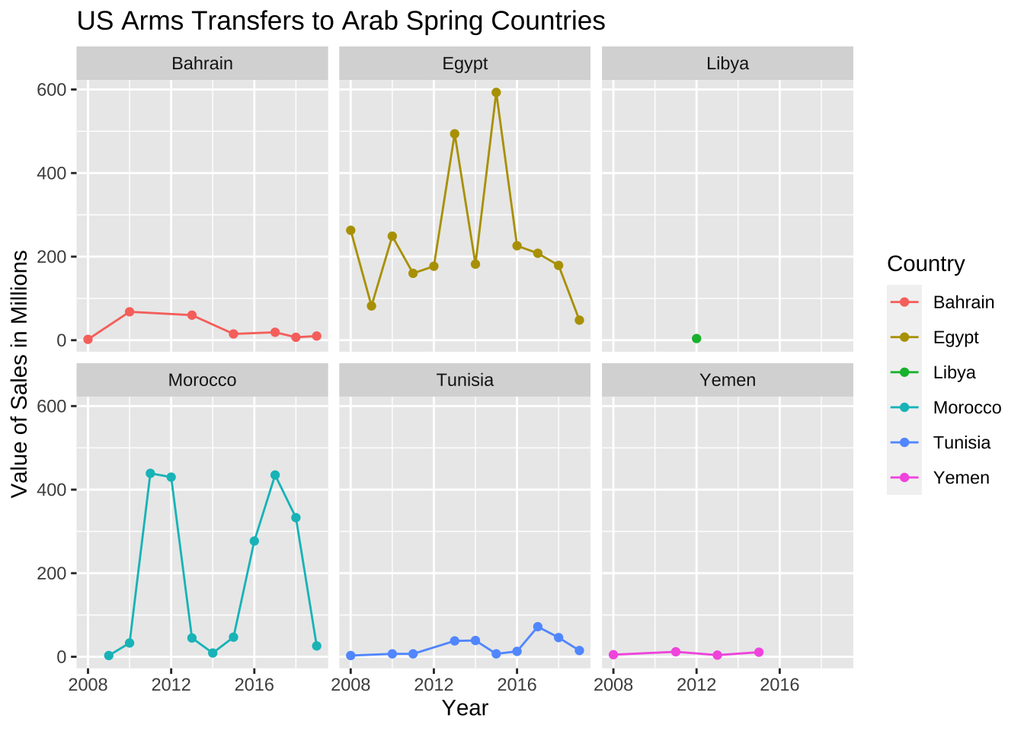

```r
Arab_Spring_Countries <- c("Egypt", "Libya", "Tunisia", "Morocco", "Yemen", "Bahrain")

Nation %>%
  filter(Country %in% Arab_Spring_Countries, Year > 2007) %>%
  ggplot(mapping = aes(x= Year, y = Value, col = Country))+
  geom_point()+
  geom_line() +
  facet_wrap(~Country)+
  labs(x= "Year",
       y= "Value of Sales in Millions",
       title = "US Arms Transfers to Arab Spring Countries")+
  scale_x_continuous(breaks = c(2008, 2012, 2016))
```

US imports from 2015 to now

```r
Top_Importers_15_to_19<-Nation %>%
  filter(Year %in% c(2015:2019))%>%
  group_by(Country) %>%
  select(Country, Value) %>%
  summarise_each(funs(sum)) %>%
  arrange(desc(Value))
Top_Importers_15_to_19
```

```
## # A tibble: 101 x 2
##    Country        Value
##    <chr>          <int>
##  1 Saudi Arabia   13004
##  2 Australia       4826
##  3 UAE             3373
##  4 South Korea     2755
##  5 Japan           2465
##  6 Qatar           2454
##  7 Israel          2242
##  8 Iraq            2232
##  9 United Kingdom  1674
## 10 Italy           1393
## # … with 91 more rows
```

```r
colnames(Nation) <- c("Year", "Country", "Value")
```

Let’s look at another hostile region of the world: The Indian Subcontinent

```r
Nation %>%
  filter(Country == c("Pakistan", "India"))%>%
  group_by(Year) %>%
  arrange(desc(Year))
```

```
## # A tibble: 52 x 3
## # Groups:   Year [48]
##     Year Country  Value
##    <int> <chr>    <int>
##  1  2019 India      641
##  2  2018 Pakistan    12
##  3  2017 India      250
##  4  2016 India       41
##  5  2015 Pakistan   107
##  6  2014 Pakistan   201
##  7  2013 Pakistan   137
##  8  2012 India      139
##  9  2011 India      203
## 10  2010 Pakistan  1027
## # … with 42 more rows
```

```r
Nation %>%
  filter(Country %in% c("Pakistan", "India"), Year %in% c(2015:2019)) %>%
  group_by(Country)
```

```
## # A tibble: 10 x 3
## # Groups:   Country [2]
##     Year Country  Value
##    <int> <chr>    <int>
##  1  2015 India      268
##  2  2015 Pakistan   107
##  3  2016 India       41
##  4  2016 Pakistan    15
##  5  2017 India      250
##  6  2017 Pakistan    21
##  7  2018 India       22
##  8  2018 Pakistan    12
##  9  2019 India      641
## 10  2019 Pakistan     3
```

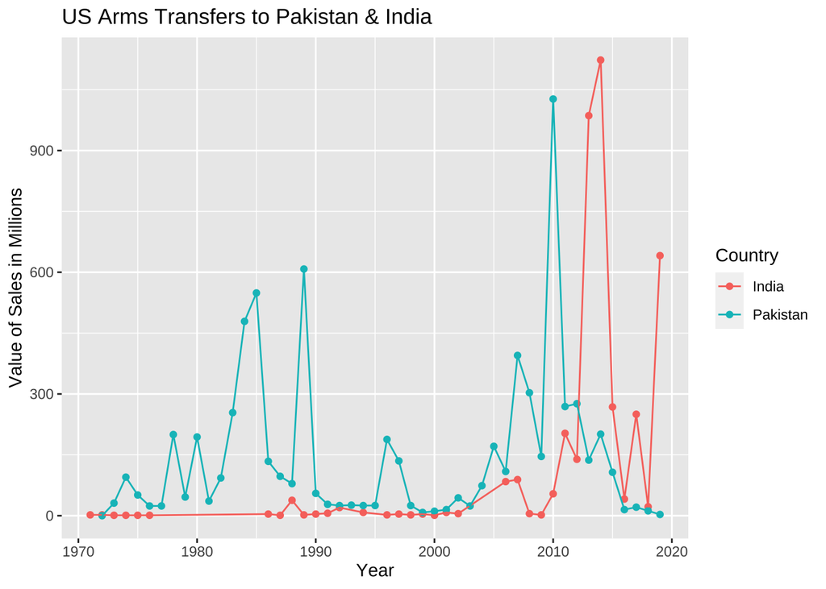

```r
Nation %>%
  filter(Country %in% c("Pakistan", "India"), Year %in% c(1971:2019)) %>%
  group_by(Country)%>%
  ggplot(mapping=aes(x= Year, y= Value, col = Country)) +
  geom_point()+
  geom_line()+
  labs(x= "Year",
       y= "Value of Sales in Millions",
       title = "US Arms Transfers to Pakistan & India")
```

US relations with India start to pick up around the time an alt right government comes into power, relations with Pakistan decline, however 2005 until present, with tensions heated, supplying arms to both sides.

China is one of the largest importers and exporters. Curious to see who exports to them. Who does China import from?

```r
China <- read.csv("/Users/inthisarkamal/Desktop/DS4PP/Final Project/China_Exports.csv")
China
```

```
##           Country X1950 X1951 X1952 X1953 X1954 X1955 X1956 X1957 X1958 X1959
## 1         Belarus    NA    NA    NA    NA    NA    NA    NA    NA    NA    NA
## 2          Canada    NA    NA    NA    NA    NA    NA    NA    NA    NA    NA
## 3          France    NA    NA    NA    NA    NA    NA    NA    NA    NA    NA
## 4         Germany    NA    NA    NA    NA    NA    NA    NA    NA    NA    NA
## 5          Israel    NA    NA    NA    NA    NA    NA    NA    NA    NA    NA
## 6           Italy    NA    NA    NA    NA    NA    NA    NA    NA    NA    NA
## 7           Japan    NA    NA    NA    NA    NA    NA    NA    NA    NA    NA
## 8          Russia    NA    NA    NA    NA    NA    NA    NA    NA    NA    NA
## 9    Soviet Union  2573  2197  3430  3144  3500  1730  2255  2126  2778  3159
## 10    Switzerland    NA    NA    NA    NA    NA    NA    NA    NA    NA    NA
## 11        Ukraine    NA    NA    NA    NA    NA    NA    NA    NA    NA    NA
## 12 United Kingdom    NA    NA    NA    NA    NA    NA    NA    NA    NA    NA
## 13  United States    NA    NA    NA    NA    NA    NA    NA    NA    NA    NA
## 14     Uzbekistan    NA    NA    NA    NA    NA    NA    NA    NA    NA    NA
```

[output cut: 104 more lines]

```r
names(China) <- gsub ("X", "", names(China))

China
```

```
##           Country 1950 1951 1952 1953 1954 1955 1956 1957 1958 1959 1960 1961
## 1         Belarus   NA   NA   NA   NA   NA   NA   NA   NA   NA   NA   NA   NA
## 2          Canada   NA   NA   NA   NA   NA   NA   NA   NA   NA   NA   NA   NA
## 3          France   NA   NA   NA   NA   NA   NA   NA   NA   NA   NA   NA   NA
## 4         Germany   NA   NA   NA   NA   NA   NA   NA   NA   NA   NA   NA   NA
## 5          Israel   NA   NA   NA   NA   NA   NA   NA   NA   NA   NA   NA   NA
## 6           Italy   NA   NA   NA   NA   NA   NA   NA   NA   NA   NA   NA   NA
## 7           Japan   NA   NA   NA   NA   NA   NA   NA   NA   NA   NA   NA   NA
## 8          Russia   NA   NA   NA   NA   NA   NA   NA   NA   NA   NA   NA   NA
## 9    Soviet Union 2573 2197 3430 3144 3500 1730 2255 2126 2778 3159 2431  936
## 10    Switzerland   NA   NA   NA   NA   NA   NA   NA   NA   NA   NA   NA   NA
## 11        Ukraine   NA   NA   NA   NA   NA   NA   NA   NA   NA   NA   NA   NA
## 12 United Kingdom   NA   NA   NA   NA   NA   NA   NA   NA   NA   NA   NA   NA
## 13  United States   NA   NA   NA   NA   NA   NA   NA   NA   NA   NA   NA   NA
## 14     Uzbekistan   NA   NA   NA   NA   NA   NA   NA   NA   NA   NA   NA   NA
```

[output cut: 70 more lines]

```r
China [2:72] <- lapply(China[2:72], as.numeric)

China
```

```
##           Country 1950 1951 1952 1953 1954 1955 1956 1957 1958 1959 1960 1961
## 1         Belarus   NA   NA   NA   NA   NA   NA   NA   NA   NA   NA   NA   NA
## 2          Canada   NA   NA   NA   NA   NA   NA   NA   NA   NA   NA   NA   NA
## 3          France   NA   NA   NA   NA   NA   NA   NA   NA   NA   NA   NA   NA
## 4         Germany   NA   NA   NA   NA   NA   NA   NA   NA   NA   NA   NA   NA
## 5          Israel   NA   NA   NA   NA   NA   NA   NA   NA   NA   NA   NA   NA
## 6           Italy   NA   NA   NA   NA   NA   NA   NA   NA   NA   NA   NA   NA
## 7           Japan   NA   NA   NA   NA   NA   NA   NA   NA   NA   NA   NA   NA
## 8          Russia   NA   NA   NA   NA   NA   NA   NA   NA   NA   NA   NA   NA
## 9    Soviet Union 2573 2197 3430 3144 3500 1730 2255 2126 2778 3159 2431  936
## 10    Switzerland   NA   NA   NA   NA   NA   NA   NA   NA   NA   NA   NA   NA
## 11        Ukraine   NA   NA   NA   NA   NA   NA   NA   NA   NA   NA   NA   NA
## 12 United Kingdom   NA   NA   NA   NA   NA   NA   NA   NA   NA   NA   NA   NA
## 13  United States   NA   NA   NA   NA   NA   NA   NA   NA   NA   NA   NA   NA
## 14     Uzbekistan   NA   NA   NA   NA   NA   NA   NA   NA   NA   NA   NA   NA
```

[output cut: 70 more lines]

```r
China_modern<-China %>%
  select(-(2:51))
China_modern
```

```
##           Country 2000 2001 2002 2003 2004 2005 2006 2007 2008 2009 2010 2011
## 1         Belarus   NA   NA   NA   NA   NA   NA   NA   NA   NA   NA   NA   NA
## 2          Canada   NA   NA   NA   NA   NA   NA   NA   NA   NA   NA   NA   NA
## 3          France   91  108  145  131  223  193  142  149  160  128  152  167
## 4         Germany    8    8    6    8   16   16   12   10    3    3    3    3
## 5          Israel   28   28   NA   NA   NA   NA   NA   NA   NA   NA   NA   NA
## 6           Italy   NA   NA   NA   NA   NA   NA   NA   NA   NA   NA   NA   NA
## 7           Japan   NA   NA   NA   NA   NA   NA   NA   NA   NA   NA   NA   NA
## 8          Russia 2231 2500 2541 2076 2887 3156 2465 1316 1514 1094  731  783
## 9    Soviet Union   NA   NA   NA   NA   NA   NA   NA   NA   NA   NA   NA   NA
## 10    Switzerland   65   65   65   65   65   65   65   65   65   65   65   65
## 11        Ukraine   29   41   58    3   33   82  128   64   54   28   NA   NA
## 12 United Kingdom   70   70   60   60   60   70   50   50   60   70   70   70
## 13  United States   NA   NA   NA   NA   NA   NA   NA   NA   NA   NA   NA   NA
## 14     Uzbekistan   NA   NA   NA   NA   NA   NA   NA   NA   NA   NA   NA   NA
```

[output cut: 19 more lines]

```r
#China_modern<-China_modern[-c(1),]
```

```r
#China_modern2 <- China_modern %>%
  #pivot_longer(`2000`:`2019`, names_to = "Year", values_to = "Total")
#print(China_modern2)
```

```r
China_modern <- China_modern [-c(241:280),]
China_modern
```

```
##           Country 2000 2001 2002 2003 2004 2005 2006 2007 2008 2009 2010 2011
## 1         Belarus   NA   NA   NA   NA   NA   NA   NA   NA   NA   NA   NA   NA
## 2          Canada   NA   NA   NA   NA   NA   NA   NA   NA   NA   NA   NA   NA
## 3          France   91  108  145  131  223  193  142  149  160  128  152  167
## 4         Germany    8    8    6    8   16   16   12   10    3    3    3    3
## 5          Israel   28   28   NA   NA   NA   NA   NA   NA   NA   NA   NA   NA
## 6           Italy   NA   NA   NA   NA   NA   NA   NA   NA   NA   NA   NA   NA
## 7           Japan   NA   NA   NA   NA   NA   NA   NA   NA   NA   NA   NA   NA
## 8          Russia 2231 2500 2541 2076 2887 3156 2465 1316 1514 1094  731  783
## 9    Soviet Union   NA   NA   NA   NA   NA   NA   NA   NA   NA   NA   NA   NA
## 10    Switzerland   65   65   65   65   65   65   65   65   65   65   65   65
## 11        Ukraine   29   41   58    3   33   82  128   64   54   28   NA   NA
## 12 United Kingdom   70   70   60   60   60   70   50   50   60   70   70   70
## 13  United States   NA   NA   NA   NA   NA   NA   NA   NA   NA   NA   NA   NA
## 14     Uzbekistan   NA   NA   NA   NA   NA   NA   NA   NA   NA   NA   NA   NA
```

[output cut: 19 more lines]

```r
China_modern %>%
  filter(!is.na(Value))
```

```
##           Country 2000 2001 2002 2003 2004 2005 2006 2007 2008 2009 2010 2011
## 1         Belarus   NA   NA   NA   NA   NA   NA   NA   NA   NA   NA   NA   NA
## 2          Canada   NA   NA   NA   NA   NA   NA   NA   NA   NA   NA   NA   NA
## 3          France   91  108  145  131  223  193  142  149  160  128  152  167
## 4         Germany    8    8    6    8   16   16   12   10    3    3    3    3
## 5          Israel   28   28   NA   NA   NA   NA   NA   NA   NA   NA   NA   NA
## 6           Italy   NA   NA   NA   NA   NA   NA   NA   NA   NA   NA   NA   NA
## 7           Japan   NA   NA   NA   NA   NA   NA   NA   NA   NA   NA   NA   NA
## 8          Russia 2231 2500 2541 2076 2887 3156 2465 1316 1514 1094  731  783
## 9    Soviet Union   NA   NA   NA   NA   NA   NA   NA   NA   NA   NA   NA   NA
## 10    Switzerland   65   65   65   65   65   65   65   65   65   65   65   65
## 11        Ukraine   29   41   58    3   33   82  128   64   54   28   NA   NA
## 12 United Kingdom   70   70   60   60   60   70   50   50   60   70   70   70
## 13  United States   NA   NA   NA   NA   NA   NA   NA   NA   NA   NA   NA   NA
## 14     Uzbekistan   NA   NA   NA   NA   NA   NA   NA   NA   NA   NA   NA   NA
```

[output cut: 17 more lines]

```r
China_modern
```

```
##           Country 2000 2001 2002 2003 2004 2005 2006 2007 2008 2009 2010 2011
## 1         Belarus   NA   NA   NA   NA   NA   NA   NA   NA   NA   NA   NA   NA
## 2          Canada   NA   NA   NA   NA   NA   NA   NA   NA   NA   NA   NA   NA
## 3          France   91  108  145  131  223  193  142  149  160  128  152  167
## 4         Germany    8    8    6    8   16   16   12   10    3    3    3    3
## 5          Israel   28   28   NA   NA   NA   NA   NA   NA   NA   NA   NA   NA
## 6           Italy   NA   NA   NA   NA   NA   NA   NA   NA   NA   NA   NA   NA
## 7           Japan   NA   NA   NA   NA   NA   NA   NA   NA   NA   NA   NA   NA
## 8          Russia 2231 2500 2541 2076 2887 3156 2465 1316 1514 1094  731  783
## 9    Soviet Union   NA   NA   NA   NA   NA   NA   NA   NA   NA   NA   NA   NA
## 10    Switzerland   65   65   65   65   65   65   65   65   65   65   65   65
## 11        Ukraine   29   41   58    3   33   82  128   64   54   28   NA   NA
## 12 United Kingdom   70   70   60   60   60   70   50   50   60   70   70   70
## 13  United States   NA   NA   NA   NA   NA   NA   NA   NA   NA   NA   NA   NA
## 14     Uzbekistan   NA   NA   NA   NA   NA   NA   NA   NA   NA   NA   NA   NA
```

[output cut: 19 more lines]

```r
China3<-China_modern %>%
  group_by(Country) %>%
  select(Country, Value) %>%
  summarise_each(funs(sum)) %>%
  arrange(desc(Value))
China3
```

```
## # A tibble: 16 x 2
##    Country          Value
##    <chr>            <dbl>
##  1 "Total"          79524
##  2 "Russia"         36282
##  3 "Soviet Union"   32511
##  4 "France"          4884
##  5 "Ukraine"         1953
##  6 "Switzerland"     1300
##  7 "United Kingdom"  1245
##  8 "Germany"          437
##  9 "Israel"           350
## 10 "United States"    211
## 11 "Belarus"          170
## 12 "Uzbekistan"       102
## 13 "Japan"             45
## 14 "Italy"             26
## 15 "Canada"             8
## 16 ""                  NA
```

```r
China3 <- China3 [-c(1),]
China3
```

```
## # A tibble: 15 x 2
##    Country          Value
##    <chr>            <dbl>
##  1 "Russia"         36282
##  2 "Soviet Union"   32511
##  3 "France"          4884
##  4 "Ukraine"         1953
##  5 "Switzerland"     1300
##  6 "United Kingdom"  1245
##  7 "Germany"          437
##  8 "Israel"           350
##  9 "United States"    211
## 10 "Belarus"          170
## 11 "Uzbekistan"       102
## 12 "Japan"             45
## 13 "Italy"             26
## 14 "Canada"             8
## 15 ""                  NA
```

```r
#China4 <- China3 [-c(3)]
```

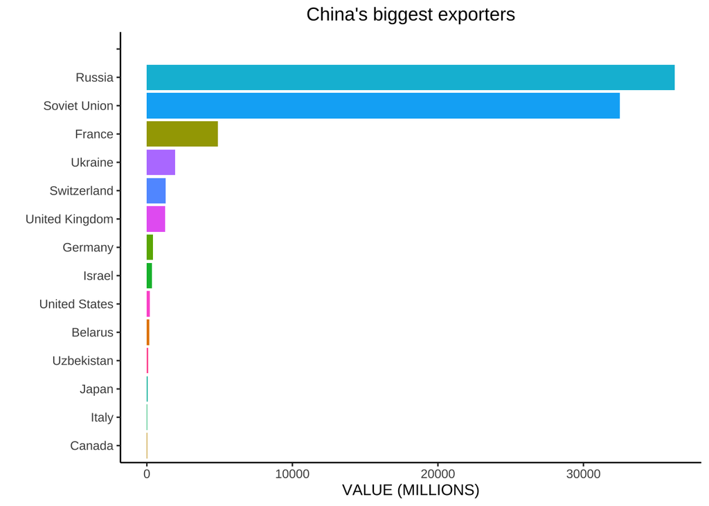

```r
China3 %>%
  group_by(Country) %>%
  select(Country, Value) %>%
  summarise_each(funs(sum)) %>%
  arrange(desc(Value))%>%
  ggplot(mapping=aes(x=fct_reorder(Country, Value, .desc = FALSE), y=Value, fill=Country))+
  geom_bar(stat = "identity", position = "dodge")+
  labs(title = "China's biggest exporters", y = "VALUE (MILLIONS)", fill=FALSE)+
  theme_classic()+
  coord_flip()+
  labs(x="")+
  theme(legend.position = "none")+
  theme(plot.title=element_text(hjust=0.5))
```

```r
China3
```

```
## # A tibble: 15 x 2
##    Country          Value
##    <chr>            <dbl>
##  1 "Russia"         36282
##  2 "Soviet Union"   32511
##  3 "France"          4884
##  4 "Ukraine"         1953
##  5 "Switzerland"     1300
##  6 "United Kingdom"  1245
##  7 "Germany"          437
##  8 "Israel"           350
##  9 "United States"    211
## 10 "Belarus"          170
## 11 "Uzbekistan"       102
## 12 "Japan"             45
## 13 "Italy"             26
## 14 "Canada"             8
## 15 ""                  NA
```

Let’s look at how big of a share of France’s exports are made up by China

```r
France <- read.csv("/Users/inthisarkamal/Desktop/DS4PP/Final Project/France Exports.csv")
```

```r
France
```

```
##                      Country X1950 X1951 X1952 X1953 X1954 X1955 X1956 X1957
## 1                      India    NA    NA    NA   156    73    NA    NA   254
## 2                       Iraq    NA    NA    NA    NA    NA    NA    NA    NA
## 3                    Germany    NA    NA    NA    NA    NA    NA    50    42
## 4                      Spain    NA    NA    NA    20    NA    40    20    NA
## 5                      China    NA    NA    NA    NA    NA    NA    NA    NA
## 6                     Greece    NA    NA    NA    NA    NA    NA    NA    NA
## 7                   Pakistan    NA    NA    NA    NA    NA    NA    NA    NA
## 8                     Taiwan    NA    NA    NA    NA    NA    NA    NA    NA
## 9                    Morocco    NA    NA    NA    NA    NA    NA    28    12
## 10                     Qatar    NA    NA    NA    NA    NA    NA    NA    NA
## 11                     Libya    NA    NA    NA    NA    NA    NA    NA    NA
## 12              South Africa    NA    NA    NA    NA    NA    NA    NA    NA
## 13             United States    NA    NA    NA    NA    NA    NA    NA    60
## 14                 Singapore    NA    NA    NA    NA    NA    NA    NA    NA
```

[output cut: 951 more lines]

```r
names(France) <- gsub ("X", "", names(France))
France
```

```
##                      Country 1950 1951 1952 1953 1954 1955 1956 1957 1958 1959
## 1                      India   NA   NA   NA  156   73   NA   NA  254  224   NA
## 2                       Iraq   NA   NA   NA   NA   NA   NA   NA   NA   NA   NA
## 3                    Germany   NA   NA   NA   NA   NA   NA   50   42  291  408
## 4                      Spain   NA   NA   NA   20   NA   40   20   NA   NA    1
## 5                      China   NA   NA   NA   NA   NA   NA   NA   NA   NA   NA
## 6                     Greece   NA   NA   NA   NA   NA   NA   NA   NA   NA   NA
## 7                   Pakistan   NA   NA   NA   NA   NA   NA   NA   NA   NA   NA
## 8                     Taiwan   NA   NA   NA   NA   NA   NA   NA   NA   NA   NA
## 9                    Morocco   NA   NA   NA   NA   NA   NA   28   12   10   13
## 10                     Qatar   NA   NA   NA   NA   NA   NA   NA   NA   NA   NA
## 11                     Libya   NA   NA   NA   NA   NA   NA   NA   NA   NA   NA
## 12              South Africa   NA   NA   NA   NA   NA   NA   NA   NA   NA   NA
## 13             United States   NA   NA   NA   NA   NA   NA   NA   60   60   60
## 14                 Singapore   NA   NA   NA   NA   NA   NA   NA   NA   NA   NA
```

[output cut: 813 more lines]

```r
France %>%
  select(Country, Total)
```

```
##                      Country  Total
## 1                      India   5624
## 2                       Iraq   5552
## 3                    Germany   5290
## 4                      Spain   4965
## 5                      China   4884
## 6                     Greece   4537
## 7                   Pakistan   4288
## 8                     Taiwan   4242
## 9                    Morocco   4012
## 10                     Qatar   3552
## 11                     Libya   3345
## 12              South Africa   3248
## 13             United States   3230
## 14                 Singapore   2788
```

[output cut: 123 more lines]

China is a significant importer of arms from France